# Homework 3 solution

# Exercise statement

Look at the barnnamn data:

1. Can you order the names by the year they peak (i.e. the year they were most popular), going from the names which peaked earliest to those that peaked latest?
2. Are there any gender biases in the initial letters of male versus female names? Create a percent stacked barplot showing the proportion of names beginning with (e.g. A, Ä, Å etc.) that are male versus female. Make sure you appropriately label your x axis, y axis and title.

# Names ordered by the year they peak

Here, you needed to use the functions `group_by` (to see the data for each name separately), `max()` (to figure out the highest value of n for that name), `filter()` (to only look at rows, i.e. years, where `n==max(n)`), and of course `arrange()` (to arrange the names by the year they peak).

If you wanted to split the task into subtasks, you could also use `mutate()` to store your calculations.

```r
barnnamn%>%
  # 1. group by name
  group_by(name)%>%
  # 2. calculate the maximum n value for that name
  mutate(max_n=max(n))%>%
  # 3. filter the data to only include the row where n==max_n
  filter(n==max_n)%>%
  # 4. arrange by year
  arrange(year)
```

| year | sex | name | n | prop | max_n |
| --- | --- | --- | --- | --- | --- |
| 1998 | M | Adis | 10 | 0.0002176752 | 10 |
| 1998 | M | Aleksandar | 17 | 0.0003700479 | 17 |
| 1998 | M | Alexander | 1066 | 0.0232041794 | 1066 |
| 1998 | M | Almir | 12 | 0.0002612103 | 12 |
| 1998 | F | Amanda | 1037 | 0.0240670256 | 1037 |
| 1998 | M | Anders | 67 | 0.0014584240 | 67 |
| 1998 | M | André | 169 | 0.0036787114 | 169 |
| 1998 | M | Andreas | 543 | 0.0118197649 | 543 |
| 1998 | M | Andréas | 10 | 0.0002176752 | 10 |
| 1998 | F | Angelica | 112 | 0.0025993316 | 112 |

[output cut: 990 more lines]

```r
# OR, a quicker way:

barnnamn%>%
  group_by(name)%>%
  filter(n==max(n))%>%
  arrange(year)
```

| year | sex | name | n | prop |
| --- | --- | --- | --- | --- |
| 1998 | M | Adis | 10 | 0.0002176752 |
| 1998 | M | Aleksandar | 17 | 0.0003700479 |
| 1998 | M | Alexander | 1066 | 0.0232041794 |
| 1998 | M | Almir | 12 | 0.0002612103 |
| 1998 | F | Amanda | 1037 | 0.0240670256 |
| 1998 | M | Anders | 67 | 0.0014584240 |
| 1998 | M | André | 169 | 0.0036787114 |
| 1998 | M | Andreas | 543 | 0.0118197649 |
| 1998 | M | Andréas | 10 | 0.0002176752 |
| 1998 | F | Angelica | 112 | 0.0025993316 |

[output cut: 990 more lines]

# Sex bias in initial letters

This was pretty straightforward, everybody did this right!

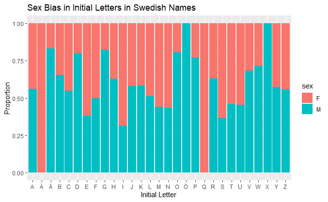

```r
barnnamn%>%
  mutate(InitialLetter=str_sub(name,1,1))%>%
  ggplot(aes(x=InitialLetter,y=n,fill=sex))+geom_col(position='fill')+labs(x='Initial Letter',y='Proportion',title="Sex Bias in Initial Letters in Swedish Names")
```

# Challenge

The challenge was to see if you could arrange the letters on the x-axis according to the proportion of females. This was a bit tricky. You needed to make another column which,for every letter separately, contained the proportion of names starting with that letter which were female, and then reorder the x-axis by this column (going in decreasing order).

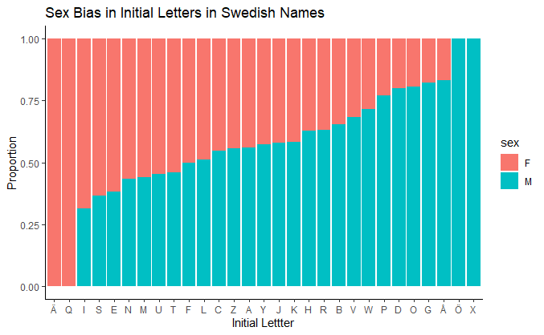

```r
barnnamn%>%
  mutate(InitialLetter=str_sub(name,1,1))%>%
  # for each initial letter separately
  group_by(InitialLetter)%>%
  # calculate the ratio of girl names (i.e. sum of n where sex==F, divided by sum of all n for that name)
  mutate(girl_ratio=sum(n[sex=="F"])/sum(n))%>%
  ggplot(aes(x=reorder(InitialLetter,-girl_ratio),y=n,fill=sex))+geom_col(position='fill')+theme_classic()+labs(x="Initial Lettter",y="Proportion",title="Sex Bias in Initial Letters in Swedish Names")
```